# aed

### 3.1.6. *diasEntrePedidos*

Esta variable está directamente relacionada con el ciclo de reposición de un producto, que es el tiempo que debe pasar para revisar el inventario de un producto concreto y decidir si se debe realizar un pedido. El valor de este atributo depende de varios factores, como la demanda del propio producto, los tiempos de entrega de los proveedores y la importancia del artículo en cuanto a las ventas de la empresa.

```python
# DataFrame con la variable diasEntrePedidos por producto
dias_pedidos_analisis: pd.DataFrame = dataset_reconstruido.groupby("producto", as_index=False).agg({
    "diasEntrePedidos": "first"
})
```

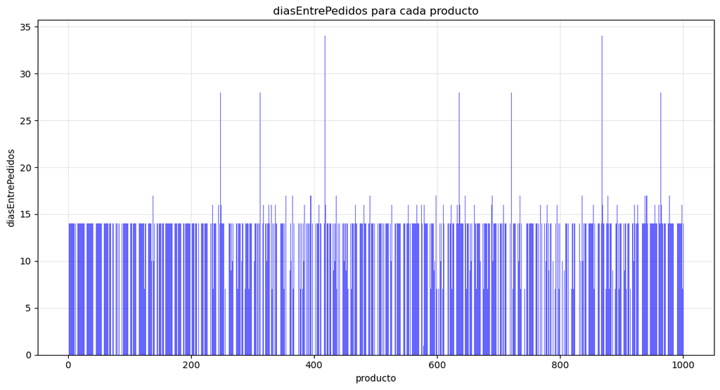

```python
# diasEntrePedidos para cada producto
plt.figure(figsize=(11, 6))

plt.bar(
    dias_pedidos_analisis["producto"],
    dias_pedidos_analisis["diasEntrePedidos"],
    color="blue",
    alpha=0.6
)

plt.title("diasEntrePedidos para cada producto")
plt.xlabel("producto")
plt.ylabel("diasEntrePedidos")

plt.grid(True, alpha=0.3)
plt.gca().set_axisbelow(True)

plt.tight_layout()
plt.show()
```

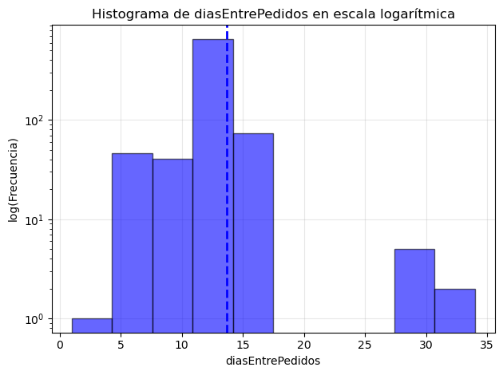

```python
# Histograma de la variable diasEntrePedidos
ax: matplotlib.axes.Axes = dias_pedidos_analisis["diasEntrePedidos"].hist(
    log=True,
    color="blue",
    edgecolor="black",
    linewidth=1,
    alpha=0.6
)

plt.axvline(
    dias_pedidos_analisis["diasEntrePedidos"].mean(),
    color="blue",
    linestyle="--",
    linewidth=2
)

ax.set_title("Histograma de diasEntrePedidos en escala logarítmica")
ax.set_xlabel("diasEntrePedidos")
ax.set_ylabel("log(Frecuencia)")

ax.grid(True, alpha=0.3)
ax.set_axisbelow(True)

plt.tight_layout()
plt.show()
```

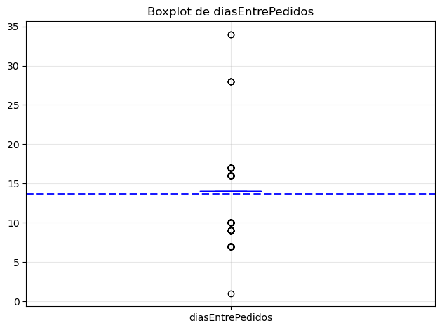

```python
# Boxplot del campo diasEntrePedidos
ax: matplotlib.axes.Axes = dias_pedidos_analisis.boxplot(
    "diasEntrePedidos",
    color="blue"
)

plt.axhline(
    dias_pedidos_analisis["diasEntrePedidos"].mean(),
    color="blue",
    linestyle="--",
    linewidth=2
)

ax.set_title("Boxplot de diasEntrePedidos")

ax.grid(True, alpha=0.3)
ax.set_axisbelow(True)

plt.tight_layout()
plt.show()
```

```python
# Los dos productos con mayor diasEntrePedidos
print(
    f"Los dos productos con el ciclo de reposición más largo son los de ID {
        ", ".join([str(n) for n in dias_pedidos_analisis.sort_values(by="diasEntrePedidos", ascending=False)["producto"].tolist()[:2]])
    }"
)
```

```
Los dos productos con el ciclo de reposición más largo son los de ID 418, 868
```

El histograma de la variable *diasEntrePedidos*, representado en escala logarítmica, muestra una distribución claramente asimétrica y con una elevada concentración de valores en rangos intermedios. La mayor parte de los productos presentan ciclos de reposición comprendidos aproximadamente entre los 8 y 15 días, lo que sugiere una política de aprovisionamiento relativamente homogénea para la mayoría de referencias. Asimismo, se observa la presencia de un grupo reducido de productos con valores significativamente más elevados, como el 418 y el 868, situados alrededor de los 35 días. El *boxplot* de la variable permite apreciar que estos casos son poco frecuentes, actuando como valores extremos, los cuales no deben eliminarse ya que estos valores no son fruto de un error en los datos. Por otro lado, el comportamiento observado sugiere la coexistencia de al menos dos tipologías de productos, los que tienen una rotación más frecuente, que requieren reposiciones periódicas en intervalos cortos, y los artículos de menor demanda o mayor estabilidad, cuyo ciclo de aprovisionamiento es más amplio.

### 3.1.7. *diasLeadtime*

Esta variable resulta muy importante para planificar las compras de productos a proveedores, ya que durante este tiempo la demanda del producto en cuestión debe quedar totalmente cubierta para evitar *stockouts*. Así pues, dado que la naturaleza de este atributo es similar a la de *diasEntrePedidos*, el análisis que se lleva a cabo es bastante similar.

```python
# DataFrame con el campo diasLeadtime por producto
lead_time_analisis: pd.DataFrame = dataset_reconstruido.groupby("producto", as_index=False).agg({
    "diasLeadtime": "first"
})
```

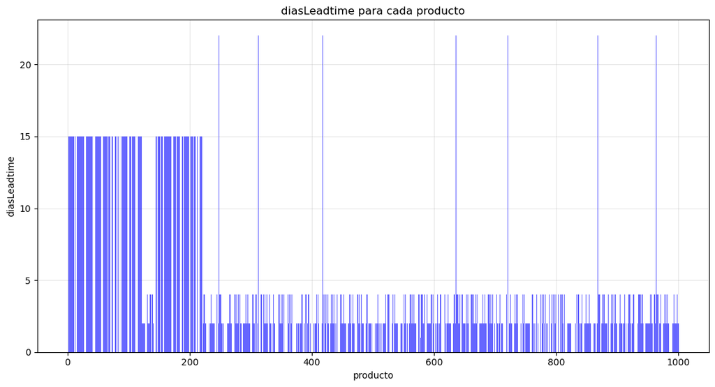

```python
# diasLeadtime para cada producto
plt.figure(figsize=(11, 6))

plt.bar(
    lead_time_analisis["producto"],
    lead_time_analisis["diasLeadtime"],
    color="blue",
    alpha=0.6
)

plt.title("diasLeadtime para cada producto")
plt.xlabel("producto")
plt.ylabel("diasLeadtime")

plt.grid(True, alpha=0.3)
plt.gca().set_axisbelow(True)

plt.tight_layout()
plt.show()
```

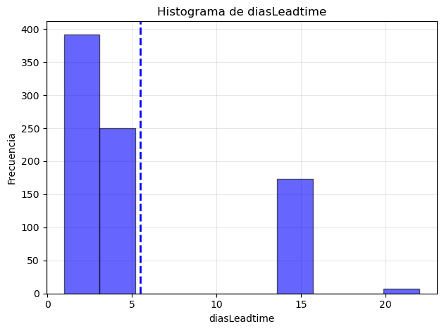

```python
# Histograma de la variable diasLeadtime
ax: matplotlib.axes.Axes = lead_time_analisis["diasLeadtime"].hist(
    color="blue",
    edgecolor="black",
    linewidth=1,
    alpha=0.6
)

plt.axvline(
    lead_time_analisis["diasLeadtime"].mean(),
    color="blue",
    linestyle="--",
    linewidth=2
)

ax.set_title("Histograma de diasLeadtime")
ax.set_xlabel("diasLeadtime")
ax.set_ylabel("Frecuencia")

ax.grid(True, alpha=0.3)
ax.set_axisbelow(True)

plt.tight_layout()
plt.show()
```

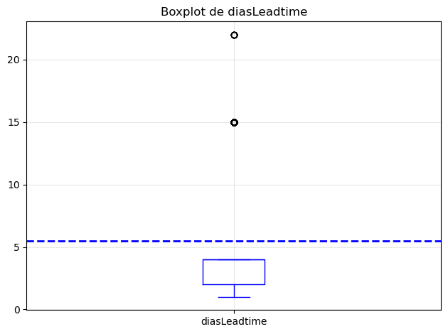

```python
# Boxplot del campo diasEntrePedidos
ax: matplotlib.axes.Axes = lead_time_analisis.boxplot(
    "diasLeadtime",
    color="blue"
)

plt.axhline(
    lead_time_analisis["diasLeadtime"].mean(),
    color="blue",
    linestyle="--",
    linewidth=2
)

ax.set_title("Boxplot de diasLeadtime")

ax.grid(True, alpha=0.3)
ax.set_axisbelow(True)

plt.tight_layout()
plt.show()
```

```python
# Los dos productos con mayor diasEntrePedidos
print(
    f"Los dos productos con el tiempo de entrega más largo son los de ID {
        ", ".join([str(n) for n in lead_time_analisis.sort_values(by="diasLeadtime", ascending=False)["producto"].tolist()[:2]])
    }"
)
```

```
Los dos productos con el tiempo de entrega más largo son los de ID 418, 248
```

La distribución de la variable *diasLeadtime* es claramente multimodal, donde se distinguen varios grupos de productos con tiempos de entrega diferenciados. En particular, la mayor parte de las referencias presentan tiempos de entrega reducidos, concentrados aproximadamente entre 1 y 5 días, lo que sugiere una cadena de suministro ágil para una parte significativa del catálogo, por lo que pueden tratarse de ítems como ambientadores o artículos de decoración del vehículo. Por otra banda, también se identifica un segundo grupo relevante de productos con tiempos de entrega entorno a los 14–15 días, lo que podría estar asociado a artículos que requieren aprovisionamiento desde ubicaciones más alejadas o proveedores con menor frecuencia de suministro. Finalmente, se observa la presencia de un número muy reducido de productos con tiempos de entrega aún mayores, cercanos a los 20 días, que pueden considerarse casos extremos dentro de la distribución, los cuales podrían ser piezas del automóvil que pueden provenir de otros países, hecho que aumenta la complejidad logística del aprovisionamiento de este tipo de artículos.

Para complementar el análisis de *diasEntrePedidos* y *diasLeadtime*, resulta interesante analizar de forma breve la variable *diasAprovisionamiento*, que es la suma de los otros dos campos mencionados. Este intervalo de tiempo se denomina intervalo de protección, y es el período de tiempo durante el cual se debe satisfacer la demanda sin poder beneficiarse de nuevas decisiones de reposición.

```python
# DataFrame con el ciclo de aprovisionamiento completo
ciclo_aprovisionamiento_analisis: pd.DataFrame = dias_pedidos_analisis.merge(
    lead_time_analisis,
    how="left",
    left_on="producto",
    right_on="producto"
)

ciclo_aprovisionamiento_analisis["diasAprovisionamiento"] = (
    ciclo_aprovisionamiento_analisis["diasEntrePedidos"]
    + ciclo_aprovisionamiento_analisis["diasLeadtime"]
)
```

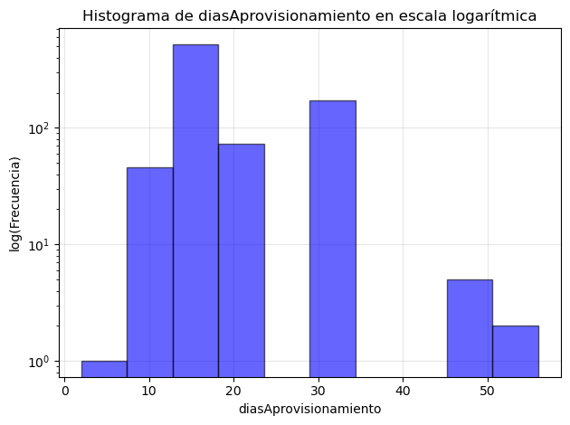

```python
# Histograma de la variable diasAprovisionamiento
ax: matplotlib.axes.Axes = ciclo_aprovisionamiento_analisis["diasAprovisionamiento"].hist(
    log=True,
    color="blue",
    edgecolor="black",
    linewidth=1,
    alpha=0.6
)

ax.set_title("Histograma de diasAprovisionamiento en escala logarítmica")
ax.set_xlabel("diasAprovisionamiento")
ax.set_ylabel("log(Frecuencia)")

ax.grid(True, alpha=0.3)
ax.set_axisbelow(True)

plt.tight_layout()
plt.show()
```

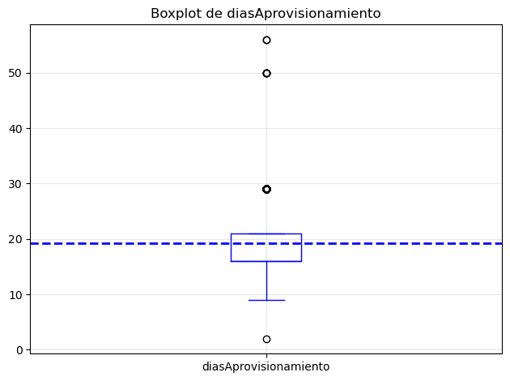

```python
# Boxplot del atributo diasAprovisionamiento
ax: matplotlib.axes.Axes = ciclo_aprovisionamiento_analisis.boxplot(
    "diasAprovisionamiento",
    color="blue"
)

plt.axhline(
    ciclo_aprovisionamiento_analisis["diasAprovisionamiento"].mean(),
    color="blue",
    linestyle="--",
    linewidth=2
)

ax.set_title("Boxplot de diasAprovisionamiento")

ax.grid(True, alpha=0.3)
ax.set_axisbelow(True)

plt.tight_layout()
plt.show()
```

El histograma logarítmico de *diasAprovisionamiento* refleja una distribución dispersa y multimodal del atributo. La mayor concentración de productos se sitúa en torno a valores intermedios, aproximadamente entre 12 y 20 días, lo que indica horizontes de aprovisionamiento relativamente cortos para la mayoría de referencias. No obstante, se identifican también grupos diferenciados con valores más elevados, entorno a los 30 días y superiores, así como algunos casos extremos que superan los 50 días. Estos valores corresponden a productos con ciclos de reposición más largos y/o mayores tiempos de entrega, lo que implica una mayor exposición al riesgo de rotura de *stock*.

### 3.1.8. *eurPrecioMedio*

El precio promedio de cada producto es una variable numérica que influye directamente en la cantidad de productos que los consumidores están dispuestos a comprar. Tal es la importancia de esta variable que la previsión de la demanda basada en el precio facilita la implementación de estrategias de precios dinámicos que se ajustan en tiempo real a las condiciones del mercado, las preferencias de los consumidores y los ingresos disponibles, permitiendo a la compañía maximizar sus beneficios.

```python
# DataFrame con el atributo eurPrecioMedio para cada artículo
precio_analisis: pd.DataFrame = dataset_reconstruido.groupby("producto", as_index=False).agg({
    "eurPrecioMedio": "first"
})
```

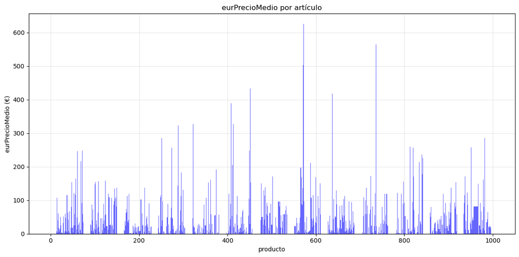

```python
# eurPrecioMedio por ítem
plt.figure(figsize=(12, 6))

plt.bar(
    precio_analisis["producto"],
    precio_analisis["eurPrecioMedio"],
    color="blue",
    alpha=0.6
)

plt.title("eurPrecioMedio por artículo")
plt.xlabel("producto")
plt.ylabel("eurPrecioMedio (€)")

plt.grid(True, alpha=0.3)
plt.gca().set_axisbelow(True)

plt.tight_layout()
plt.show()
```

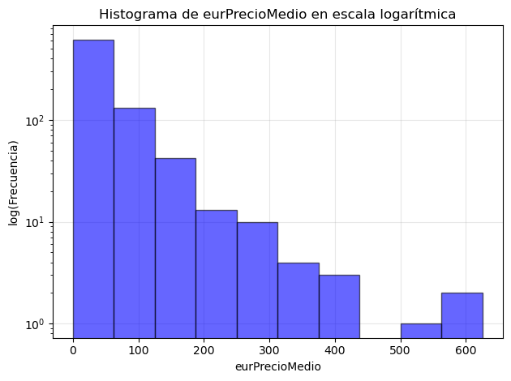

```python
# Histograma de eurPrecioMedio
ax: matplotlib.axes.Axes = precio_analisis["eurPrecioMedio"].hist(
    log=True,
    color="blue",
    edgecolor="black",
    linewidth=1,
    alpha=0.6
)

ax.set_title("Histograma de eurPrecioMedio en escala logarítmica")
ax.set_xlabel("eurPrecioMedio")
ax.set_ylabel("log(Frecuencia)")

ax.grid(True, alpha=0.3)
ax.set_axisbelow(True)

plt.tight_layout()
plt.show()
```

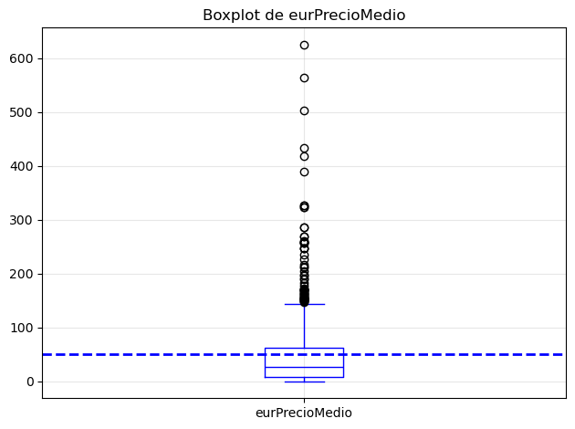

```python
# Boxplot del campo eurPrecioMedio
ax: matplotlib.axes.Axes = precio_analisis.boxplot(
    "eurPrecioMedio",
    color="blue"
)

plt.axhline(
    precio_analisis["eurPrecioMedio"].mean(),
    color="blue",
    linestyle="--",
    linewidth=2
)

ax.set_title("Boxplot de eurPrecioMedio")

ax.grid(True, alpha=0.3)
ax.set_axisbelow(True)

plt.tight_layout()
plt.show()
```

```python
# Los cinco ítems de mayor precio promedio
print(
    f"Los productos con el precio medio de venta más alto son los de ID {
        ", ".join([str(n) for n in precio_analisis.sort_values(by="eurPrecioMedio", ascending=False)["producto"].tolist()[:5]])
    }"
)
```

```
Los productos con el precio medio de venta más alto son los de ID 572, 736, 571, 452, 637
```

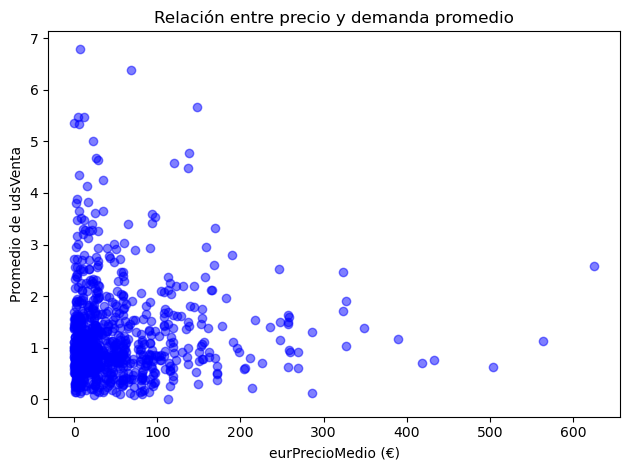

```python
# Precio promedio frente a la demanda media
precio_demanda_analisis: pd.DataFrame = dataset.groupby("producto").agg(
    precio=("eurPrecioMedio", "first"),
    demanda_media=("udsVenta", "mean")
)

plt.scatter(
    precio_demanda_analisis["precio"],
    precio_demanda_analisis["demanda_media"],
    color="blue",
    alpha=0.5
)

plt.title("Relación entre precio y demanda promedio")
plt.xlabel("eurPrecioMedio (€)")
plt.ylabel("Promedio de udsVenta")

plt.tight_layout()
plt.show()
```

La distribución logarítmica de la variable *eurPrecioMedio* muestra una concentración de productos en rangos de precio bajos y una larga cola hacia valores altos. Este comportamiento se confirma en el *boxplot*, donde se observa una mediana reducida y la presencia de numerosos valores atípicos asociados a productos de mayor precio. Este patrón refleja un catálogo heterogéneo, en el que predominan productos económicos junto con un número reducido de referencias de alto valor. Este hecho se ve reforzado al analizar la relación entre el precio y la demanda promedio, donde se observa una tendencia inversa donde los productos más baratos presentan, en general, mayores niveles de demanda, mientras que los más caros tienden a concentrarse en valores más bajos. Esto puede sugerir que los productos más costosos pueden ser de baja urgencia en el contexto de la empresa, siendo productos del automóvil que únicamente son necesarios en casos extremos como averías o accidentes.

## 3.2. Análisis de la variable objetivo

La demanda histórica de cada producto es la variable que se desea predecir a futuro, cuyo impacto en la gestión de un almacén es de suma importancia para optimizar los inventarios y reducir los costes. Por lo tanto, se dedica un apartado a su análisis donde, además de analizar la distribución de este atributo, también se aplica la prueba de *Dickey-Fuller* para comprobar si las propiedades estadísticas de esta variable se mantienen constantes a lo largo del tiempo, lo cual se presupone en algunos modelos predictivos que se aplicarán más adelante.

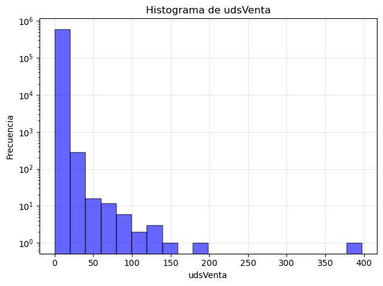

```python
# Histograma de udsVenta
ax: matplotlib.axes.Axes = dataset_reconstruido["udsVenta"].hist(
    log=True,
    bins=20,
    color="blue",
    edgecolor="black",
    linewidth=1,
    alpha=0.6
)

ax.set_title("Histograma de udsVenta")
ax.set_xlabel("udsVenta")
ax.set_ylabel("Frecuencia")

ax.grid(True, alpha=0.3)
ax.set_axisbelow(True)

plt.tight_layout()
plt.show()
```

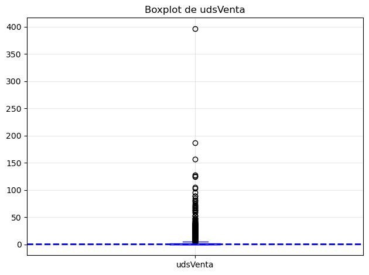

```python
# Boxplot de la variable objetivo
ax: matplotlib.axes.Axes = dataset_reconstruido.boxplot(
    "udsVenta",
    color="blue"
)

plt.axhline(
    dataset_reconstruido["udsVenta"].mean(),
    color="blue",
    linestyle="--",
    linewidth=2
)

ax.set_title("Boxplot de udsVenta")

ax.grid(True, alpha=0.3)
ax.set_axisbelow(True)

plt.tight_layout()
plt.show()
```

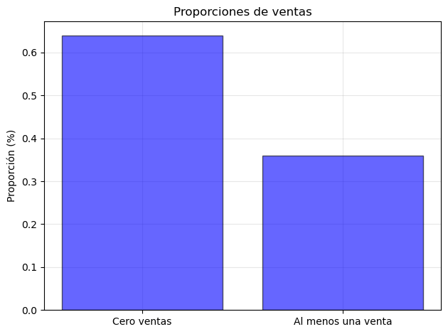

```python
# Proporción de días con 0 ventas por producto
cero_ventas: int = dataset_reconstruido[dataset_reconstruido["udsVenta"] == 0].shape[0]
total: int = dataset_reconstruido.shape[0]
prop_cero_ventas: float = round(cero_ventas / total, 2)

plt.bar(
    ["Cero ventas", "Al menos una venta"],
    [prop_cero_ventas, 1 - prop_cero_ventas],
    color="blue",
    edgecolor="black",
    linewidth=1,
    alpha=0.6
)

plt.title("Proporciones de ventas")
plt.ylabel("Proporción (%)")

plt.grid(True, alpha=0.3)
plt.gca().set_axisbelow(True)

plt.tight_layout()
plt.show()
```

```python
# Los dos productos que registraron más ventas en un solo día
productos: List[int] = dataset_reconstruido.sort_values(by="udsVenta", ascending=False)["producto"].tolist()[:2]
ventas: List[int] = dataset_reconstruido.sort_values(by="udsVenta", ascending=False)["udsVenta"].tolist()[:2]

print(
    f"Los productos con ID {", ".join([str(n) for n in productos])} obtuvieron un total de {", ".join(str(n) for n in ventas)} "
    "ventas en un solo día, respectivamente"
)
```

```
Los productos con ID 669, 228 obtuvieron un total de 397.0, 187.0 ventas en un solo día, respectivamente
```

La empresa acostumbra a registrar ventas de menos de 50 unidades por producto en la gran mayoría de artículos, donde en la mayoría de casos no se produce ninguna transacción. Por otro lado, existe un pequeño subconjunto de ventas que se encuentran entre las 50 y las 200 unidades en un solo día, lo cual puede deberse a casos excepcionales donde productos de alta necesidad fueron sujetos a un promoción en un momento muy concreto donde la demanda era muy alta. Por último, existen dos días en que se registraron 397 y 187 ventas de un solo producto, siendo estos los de ID 669 y 228, lo cual son casos excepcionales que han ocurrido únicamente dos veces en dos años.

Teniendo esto en cuenta, con el objetivo de ilustrar la demanda de un conjunto de ítems del *dataset*, se representa dicha variable de 4 artículos de los que se han observado características interesantes a lo largo del análisis exploratorio. Estos son el 669, que presenta el día con el mayor número de ventas de todo el conjunto de datos, el 572, que tiene el precio de venta más alto de todo el juego de datos, el 544, cuyas ventas son las que más mejoran cuando se incluye en una promoción, y el 904, cuyas ventas se desploman considerablemente cuando se pone en oferta.

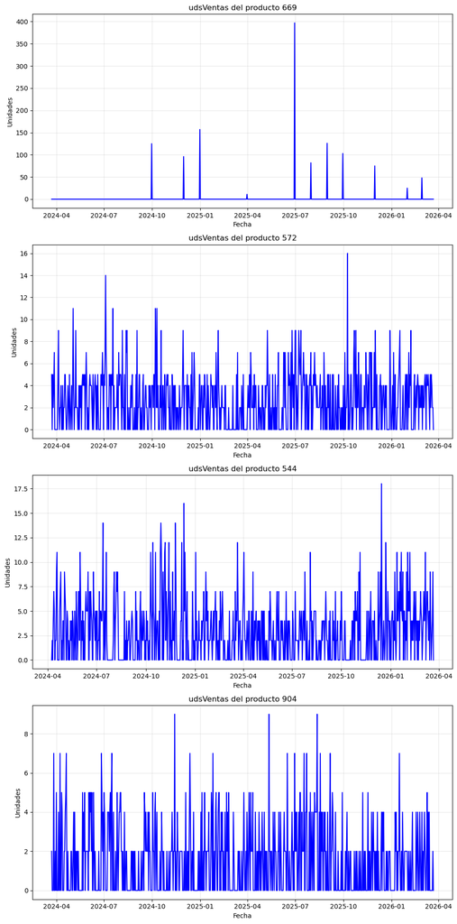

```python
# Se grafica la demanda de los 4 productos mencionados
productos: List[int] = [669, 572, 544, 904]

fig, axs = plt.subplots(nrows=len(productos), ncols=1, figsize=(10, 20))

for ax, producto in zip(axs, productos):
    dataframe_producto: pd.DataFrame = dataset_reconstruido[dataset_reconstruido["producto"] == producto]

    ax.plot(
        dataframe_producto["fecha"],
        dataframe_producto["udsVenta"],
        color="blue"
    )

    ax.set_title(f"udsVentas del producto {producto}")
    ax.set_xlabel("Fecha")
    ax.set_ylabel("Unidades")
    ax.grid(True, alpha=0.3)
    ax.set_axisbelow(True)

plt.tight_layout()
plt.show()
```

Las series temporales representadas permiten inferir posibles diferencias en la naturaleza de los productos. En el caso del ítem con mayor número de ventas en un solo día, el 669, se observa una demanda altamente intermitente con picos muy pronunciados, lo que sugiere que podría tratarse de un artículo de alta rotación sujeto a eventos puntuales o campañas específicas, como consumibles o productos ampliamente demandados en determinadas situaciones. Por el contrario, el producto con mayor precio, el 572 presenta una demanda más contenida y relativamente estable, con valores bajos y sin picos extremos, lo que resulta coherente con artículos de mayor coste asociados a necesidades específicas o menos frecuentes, como componentes más técnicos o de sustitución. Esto mismo también ocurre con los otros dos productos, el 544 y el 904, ya que también se observa un patrón de demanda constante a lo largo de toda la serie.

```python
# Función que aplica el test de Dickey-Fuller a una serie temporal
def test_adf(serie: pd.Series, producto: int, nivel_significancia=0.05) -> None:
    """Aplica la prueba de Dickey-Fuller a una serie de la demanda histórica de un producto y muestra
    los resultados.

    Argumentos:
        serie: pd.Series -> Serie temporal de un producto concreto
        producto: int -> ID del producto de la serie temporal
        nivel_significancia: float -> Umbral de probabilidad para decidir si el resultado es estadísticamente
        significativo

    Devuelve:
        None
    """
    resultado: Tuple[Any] = adfuller(serie)

    print(f"Estadístico ADF: {resultado[0]:.4f}")
    print(f"p-valor: {resultado[1]:.4f}")

    if resultado[1] < nivel_significancia:
        print(f"La serie del producto {producto} sí es estacionaria")
    else:
        print(f"La serie del producto {producto} no es estacionaria")
```

```python
# Estacionariedad de la demanda de los productos 669, 572, 544 y 904
for producto in productos:
    serie: pd.Series = dataset_reconstruido[dataset_reconstruido["producto"] == producto]["udsVenta"]
    test_adf(serie, producto)
    print("\n")
```

```
Estadístico ADF: -27.1962
p-valor: 0.0000
La serie del producto 669 sí es estacionaria


Estadístico ADF: -3.7727
p-valor: 0.0032
La serie del producto 572 sí es estacionaria


Estadístico ADF: -3.7155
p-valor: 0.0039
La serie del producto 544 sí es estacionaria


Estadístico ADF: -7.2964
p-valor: 0.0000
La serie del producto 904 sí es estacionaria
```

La aplicación del test de *Dickey-Fuller* a las series temporales de los productos analizados demuestra que estas pueden considerarse estacionarias. Este resultado es coherente con la apariencia de los gráficos, donde no se observa una tendencia clara a largo plazo ni cambios estructurales en el nivel medio de la serie. En particular, el producto 669, a pesar de presentar un comportamiento altamente intermitente con numerosos días sin ventas y picos puntuales, mantiene una media y variabilidad relativamente constantes en el tiempo. Por su parte, los productos 572, 544 y 904, muestran una evolución más estable y con menor dispersión, reforzando visualmente la ausencia de tendencia.

A modo de ejemplificar un caso donde la serie temporal de la demanda no es estacionaria, se analiza el caso del producto número 7. El gráfico de la demanda de este artículo permite intuir esta propiedad en este caso, ya que a mediados del año 2025 se observa una demanda alta y constante con apenas días sin ventas, hecho que no ocurrió en la misma época del año 2024. Este comportamiento no estacionario se ve reforzado con la aplicación de la prueba *Dickey-Fuller*, donde el *p-valor* de 0.5 unidades es mayor que el nivel de significancia establecido y, por lo tanto, se acepta la hipótesis nula que plantea que la serie temporal no es estacionaria.

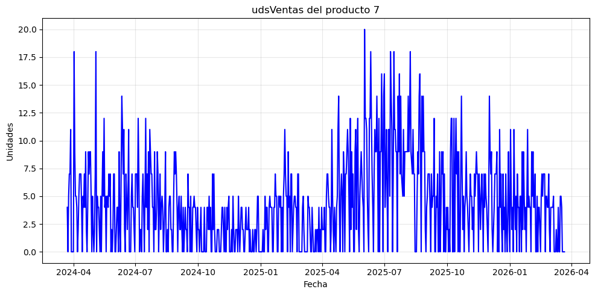

```python
# Ejemplo de serie temporal no estacionaria
producto: int = 7
plt.figure(figsize=(10, 5))

dataframe_producto: pd.DataFrame = dataset_reconstruido[dataset_reconstruido["producto"] == producto]
plt.plot(dataframe_producto["fecha"], dataframe_producto["udsVenta"], color="blue")

plt.title(f"udsVentas del producto {producto}")
plt.xlabel("Fecha")
plt.ylabel("Unidades")

plt.grid(True, alpha=0.3)
plt.gca().set_axisbelow(True)

plt.tight_layout()
plt.show()
```

```python
# Test Dickey-Fuller aplicado a una serie no estacionaria
serie: pd.Series = dataset_reconstruido[dataset_reconstruido["producto"] == producto]["udsVenta"]
test_adf(serie, producto)
```

```
Estadístico ADF: -1.5187
p-valor: 0.5242
La serie del producto 7 no es estacionaria
```

A modo de conclusión en cuanto a la estacionariedad de las series temporales, se observa que algunos productos sí que describen un comportamiento de este tipo mientras que algunos otros no. Esto es especialmente relevante en cuanto a la aplicación de modelos predictivos estadísticos, los cuales asumen que los datos son estacionarios. No obstante, algunos de estos métodos permiten transformar internamente las series temporales para que cumplan esta condición mediante la diferenciación de puntos continuos. Esto se lleva a cabo de forma automática, ya que los propios modelos se encargan de ajustar el grado de diferenciación necesario, por lo que no resulta imprescindible aplicar transformaciones manuales a todas las series.

## 3.3. Análisis conjunto

Una vez se han analizado todas las variables que se introducirán en los *datasets* que se usarán como *input* en los modelos predictivos, se lleva a cabo un breve análisis conjunto donde se examinan las correlaciones entre todos los atributos del juego de datos.

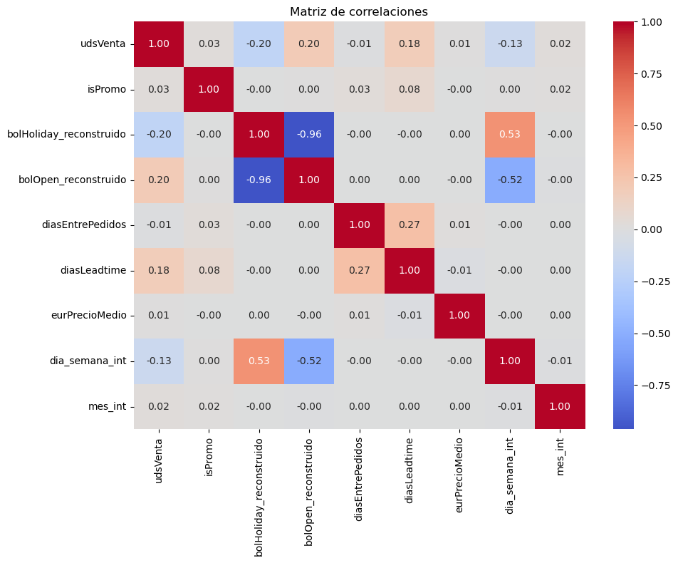

```python
corr: pd.DataFrame = dataset_reconstruido[[
    "udsVenta",
    "isPromo",
    "bolHoliday_reconstruido",
    "bolOpen_reconstruido",
    "diasEntrePedidos",
    "diasLeadtime",
    "eurPrecioMedio",
    "dia_semana_int",
    "mes_int"
]].corr()

plt.figure(figsize=(10, 8))
sns.heatmap(corr, annot=True, cmap="coolwarm", fmt=".2f", center=0)
plt.title("Matriz de correlaciones")

plt.tight_layout()
plt.show()
```

La matriz de correlación muestra que ninguna de las variables explicativas presenta una relación lineal fuerte con la variable objetivo, observándose en todos los casos coeficientes de baja magnitud. En particular, variables como las promociones o el precio medio presentan correlaciones prácticamente nulas, mientras que otras como el *lead time* o la apertura del establecimiento muestran relaciones ligeramente positivas, aunque débiles. Este resultado sugiere que la demanda no depende de forma lineal de ninguna de las variables consideradas de manera aislada, sino que su comportamiento está influido por múltiples factores y, posiblemente, por interacciones entre ellos. Asimismo, cabe destacar la fuerte correlación negativa entre *bolHoliday_reconstruido* y *bolOpen_reconstruido*, lo cual es coherente desde un punto de vista operativo, ya que los días festivos suelen coincidir con el cierre del establecimiento. Por otro lado, *dia_semana_int* tiene una correlación positiva con *bolHoliday_reconstruido*, hecho que se debe a que la mayoría de días festivos en el *dataset* caen en días a final de la semana. Sin embargo, ocurre lo contrario entre los días de la semana y *bolOpen_reconstruido*, dado que la mayoría de días que la tienda abre se encuentran al inicio de este período.

Por otro lado, esta ausencia de de correlaciones lineales fuertes observada no implica que las variables carezcan de capacidad explicativa, ya que su efecto puede depender del tipo de producto considerado. Esto sucede porque estos valores se han calculado sobre el conjunto completo de productos, lo que puede ocultar relaciones existentes a nivel individual. Dado que el *dataset* está compuesto por múltiples series temporales de distintos artículos, es posible que determinadas variables presenten una relación significativa con la demanda en algunos ítems concretos, mientras que en otros dicha relación sea inexistente o incluso opuesta. Este fenómeno puede diluir las correlaciones globales, dando lugar a coeficientes reducidos que no reflejan adecuadamente el comportamiento real de la demanda a nivel individual. Este hecho plantea la posibilidad de segmentar los productos en grupos homogéneos, de modo que las relaciones entre variables puedan analizarse de forma más precisa y ser mejor aprovechadas en los modelos de predicción.

Dicho esto, se procede a visualizar los datos a nivel de producto mediante técnicas de reducción de la dimensionalidad como *PCA*, que permite capturar relaciones lineales entre las variables, y *t-SNE*, que también puede capturar relaciones no lineales. El objetivo es analizar la estructura interna de los productos en función de sus características agregadas. Estas características son atributos que o bien se han creado en algún momento del análisis exploratorio o bien son variables como *eurPrecioMedio* o *diasEntrePedidos* que se expresan a nivel de artículo. A continuación se describen brevemente los distintos campos agregados.

- Variables a nivel de producto → *diasEntrePedidos*, *diasLeadtime*, *eurPrecioMedio*
- *promedio_ventas* → Media aritmética de *udsVenta* por producto
- *std_ventas* → Desviación estándar de *udsVenta* por producto
- *pct_cero_ventas* → Porcentaje de cero ventas en el histórico de la demanda por producto
- *pct_promo* → Porcentaje de días en los que el producto formó parte de una oferta
- *mejora_promo* → Diferencia entre el promedio de ventas cuando el producto forma parte de una promoción y cuando no está en oferta

```python
# DataFrame con información distintiva de cada producto
subset = dataset_reconstruido.groupby("producto", as_index=False).agg(
    promedio_ventas=("udsVenta", "mean"),
    pct_cero_ventas=("udsVenta", lambda g: (g == 0).mean()),
    std_ventas=("udsVenta", "std"),
    pct_promo=("isPromo", "mean"),
    promedio_ventas_promo=("udsVenta", lambda g: g[dataset_reconstruido.loc[g.index, "isPromo"] == 1].mean()),
    promedio_ventas_no_promo=("udsVenta", lambda g: g[dataset_reconstruido.loc[g.index, "isPromo"] == 0].mean()),
    diasEntrePedidos=("diasEntrePedidos", "first"),
    diasLeadtime=("diasLeadtime", "first"),
    eurPrecioMedio=("eurPrecioMedio", "first")
)

subset["mejora_promo"] = subset["promedio_ventas_promo"] - subset["promedio_ventas_no_promo"]
subset["mejora_promo"] = subset["mejora_promo"].fillna(0)
subset.drop(["promedio_ventas_promo", "promedio_ventas_no_promo"], axis=1, inplace=True)
```

```python
# Estandarización de las variables
X: pd.DataFrame = subset.drop("producto", axis=1)

scaler: StandardScaler = StandardScaler()
X_escalado: np.ndarray = scaler.fit_transform(X)
```

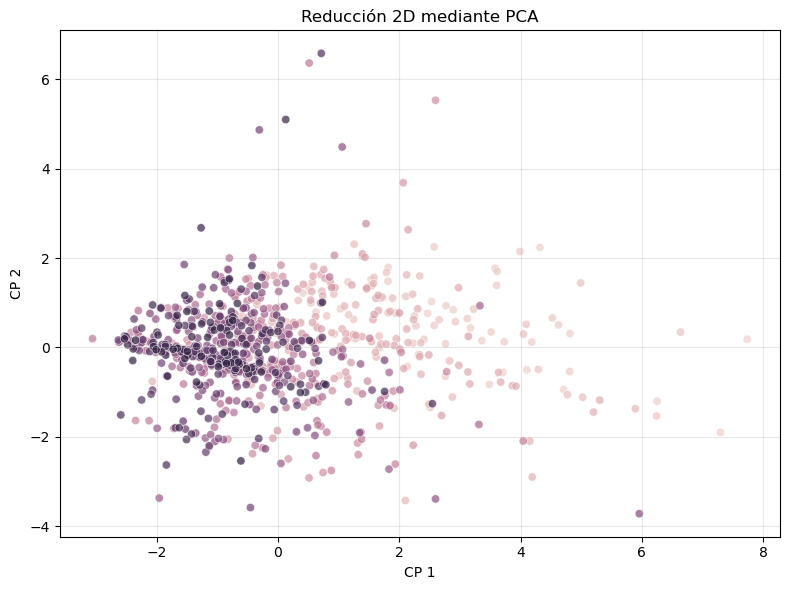

```python
# PCA y gráfico en dos dimensiones
pca: PCA = PCA(n_components=2)
pca_x: np.ndarray = pca.fit_transform(X_escalado)

plt.figure(figsize=(8, 6))

sns.scatterplot(
    x=pca_x[:, 0],
    y=pca_x[:, 1],
    hue=subset["producto"],
    alpha=0.7
)

plt.title("Reducción 2D mediante PCA")
plt.xlabel("CP 1")
plt.ylabel("CP 2")

plt.grid(True, alpha=0.3)
plt.legend("", frameon=False)

plt.tight_layout()
plt.show()
```

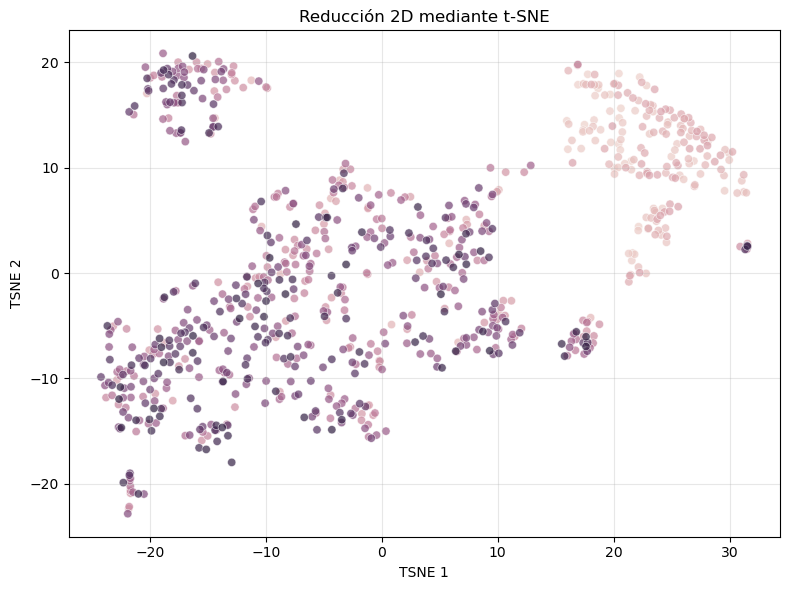

```python
# t-SNE y gráfico en dos dimensiones
SEMILLA: int = 42

tsne: TSNE = TSNE(n_components=2, perplexity=50, learning_rate="auto", max_iter=1000, random_state=SEMILLA)
tsne_x = tsne.fit_transform(X_escalado)

plt.figure(figsize=(8, 6))

sns.scatterplot(
    x=tsne_x[:,0],
    y=tsne_x[:,1],
    hue=subset["producto"],
    alpha=0.7
)

plt.title("Reducción 2D mediante t-SNE")
plt.xlabel("TSNE 1")
plt.ylabel("TSNE 2")

plt.grid(True, alpha=0.3)
plt.legend("", frameon=False)

plt.tight_layout()
plt.show()
```

En el caso de *PCA*, se observa una distribución relativamente continua de los datos, sin una separación clara entre grupos, lo que sugiere que las diferencias entre productos no se explican únicamente mediante combinaciones lineales de las variables consideradas. Por otro lado, la proyección mediante *t-SNE* revela la existencia de agrupaciones más definidas, con varios núcleos de puntos claramente diferenciados en el espacio reducido. Esto indica que, aunque las relaciones entre variables no son lineales, como ya se observó en la matriz de correlación, sí existen patrones estructurales en los datos que permiten distinguir distintos tipos de productos en función de su comportamiento.

A modo de conclusión, estos resultados refuerzan la hipótesis de que los productos presentan una heterogeneidad significativa y que es posible agruparlos en grupos homogéneos, lo que justifica la aplicación de técnicas de *clustering*.

## 4. *Clustering*

Durante los distintos apartados de este *notebook*, se ha demostrado que los productos presentan características heterogéneas, ya que algunos presentan tendencias estacionarias y otros que no, algunos tienen picos de demanda muy esporádicos, y otros presentan series temporales muy volátiles. Estas diferencias entre los patrones de la demanda provocan que todos los artículos difícilmente pueden pronosticarse de la misma manera. Esto resulta especialmente relevante para el entrenamiento de los modelos de aprendizaje automático, donde se concibe la posibilidad de entrenar modelos que incluyan múltiples productos parecidos entre sí. Dicho esto, la heterogeneidad observada en los datos implica la necesidad de agrupar los productos del juego de datos en base a sus similitudes.

Para esta tarea se emplea el algoritmo *k-means*, que es un modelo no supervisado que se basa en la minimización de la varianza dentro de los grupos mediante el cálculo de distancias y centroides. Una particularidad de este algoritmo es que se debe fijar un número de grupos antes de ejecutarlo, de manera que, para encontrar el número óptimo de *clusters*, se lanza el algoritmo para una serie de valores de grupos y para cada uno se calcula la suma de errores cuadráticos. El resultado de este proceso es el gráfico *Regla del codo del algoritmo k-means*, donde la suma de errores cuadráticos disminuye a medida que se aumenta el número de *clusters*. Consecuentemente, se considera que el valor óptimo de grupos es el que se sitúa en el codo de la visualización, siendo 10 en este caso, ya que valores más grandes implican una reducción del error demasiado baja a cambio de introducir un número de grupos demasiado elevado, dificultando la interpretación de cada *cluster*.

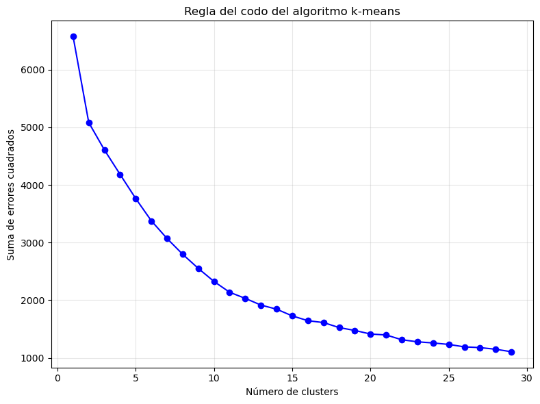

```python
# Selección del mejor número de clusters para k-means
k_INI: int = 1
k_FIN: int = 30
n_INI: int = 10

sse_k: List[float] = []
for k in range(k_INI, k_FIN):
    # Se inicializa la clase KMeans() y se aplica a los datos
    modelo_kmeans: KMeans = KMeans(n_clusters=k, n_init=n_INI, random_state=SEMILLA)
    modelo_kmeans.fit(X_escalado)

    # Se recogen las etiquetas de los datos y los centroides de sus grupos asignados
    etiquetas: np.ndarray = modelo_kmeans.labels_
    centroides: np.ndarray = modelo_kmeans.cluster_centers_

    # Se empareja cada dato con su centroide
    asignacion: Dict[Tuple[Any], np.ndarray] = {tuple(x): centroides[etiqueta] for x, etiqueta in zip(X_escalado, etiquetas)}

    # Se calcula la suma de errores cuadráticos
    sse: int = 0
    for (punto, centroide), etiqueta in zip(asignacion.items(), etiquetas):
        p: np.ndarray = np.array(punto)
        c: np.ndarray = np.array(centroide)
        sse += np.linalg.norm(p - c)**2
    sse_k.append(round(sse, 2))

# Se visualizan los resultados
plt.figure(figsize=(8, 6))
plt.plot(range(k_INI, k_FIN), sse_k, color="blue")
plt.scatter(range(k_INI, k_FIN), sse_k, marker="o", color="blue")

plt.title(f"Regla del codo del algoritmo k-means")
plt.xlabel("Número de clusters")
plt.ylabel("Suma de errores cuadrados")

plt.grid(True, alpha=0.3)
plt.gca().set_axisbelow(True)

plt.tight_layout()
plt.show()
```

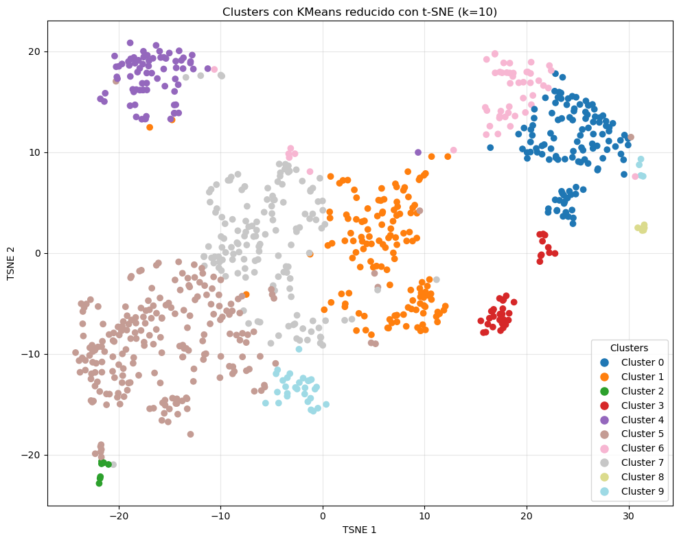

```python
# Aplicación de k-means con el mejor número de clusters y visualización con t-SNE
n_CLUSTERS: int = 10

modelo_kmeans_opt: KMeans = KMeans(n_clusters=n_CLUSTERS, n_init=n_INI, random_state=SEMILLA)
modelo_kmeans_opt.fit(X_escalado)

plt.figure(figsize=(10, 8))

etiquetas: np.ndarray = modelo_kmeans_opt.labels_
scatter: plt.scatter = plt.scatter(tsne_x[:, 0], tsne_x[:, 1], c=etiquetas, cmap="tab20")

plt.title("Clusters con KMeans reducido con t-SNE (k=10)")
plt.xlabel("TSNE 1")
plt.ylabel("TSNE 2")

plt.grid(True, alpha=0.3)
plt.gca().set_axisbelow(True)

valores_unicos: np.ndarray = np.unique(etiquetas)
norm: Normalize = Normalize(vmin=etiquetas.min(), vmax=etiquetas.max())

handles: list[Line2D] = []
labels_leyenda: list[str] = []

for v in valores_unicos:
    color = scatter.cmap(norm(v))

    handles.append(
        Line2D([0], [0], marker="o", linestyle="", markerfacecolor=color,
               markeredgecolor=color, markersize=8)
    )
    labels_leyenda.append(f"Cluster {int(v)}")

plt.legend(handles, labels_leyenda, title="Clusters")

plt.tight_layout()
plt.show()
```

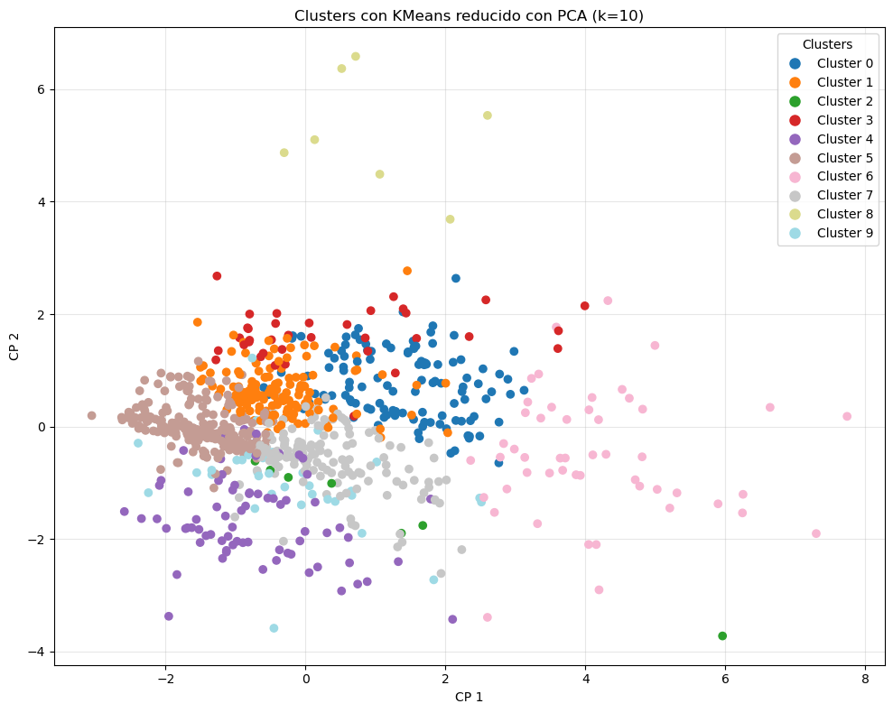

```python
# Aplicación de k-means con el mejor número de clusters y visualización con PCA
plt.figure(figsize=(10, 8))

etiquetas: np.ndarray = modelo_kmeans_opt.labels_
scatter: plt.scatter = plt.scatter(pca_x[:, 0], pca_x[:, 1], c=etiquetas, cmap="tab20")

plt.title("Clusters con KMeans reducido con PCA (k=10)")
plt.xlabel("CP 1")
plt.ylabel("CP 2")

plt.grid(True, alpha=0.3)
plt.gca().set_axisbelow(True)

valores_unicos: np.ndarray = np.unique(etiquetas)
norm: Normalize = Normalize(vmin=etiquetas.min(), vmax=etiquetas.max())

handles: list[Line2D] = []
labels_leyenda: list[str] = []

for v in valores_unicos:
    color = scatter.cmap(norm(v))

    handles.append(
        Line2D([0], [0], marker="o", linestyle="", markerfacecolor=color,
               markeredgecolor=color, markersize=8)
    )
    labels_leyenda.append(f"Cluster {int(v)}")

plt.legend(handles, labels_leyenda, title="Clusters")

plt.tight_layout()
plt.show()
```

La proyección mediante *PCA* no presenta una separación clara entre los productos, mientras que el uso de *t-SNE* muestra la existencia de *clusters* claramente diferenciados, junto con otros grupos más difusos y algunos conjuntos pequeños de productos con comportamientos atípicos esparcidos por distintas partes del plano bidimensional de *t-SNE*. Este comportamiento sugiere la existencia de relaciones no lineales entre las variables, que no son capturadas por métodos lineales como PCA. Además, esta estructura refuerza la necesidad de segmentar el dataset antes del modelado, permitiendo el entrenamiento de modelos específicos para grupos homogéneos. Dicho esto, para poder analizar qué caracteriza a cada *cluster*, se visualiza la distribución de los tamaños de cada grupo junto con un *heatmap* que resalta las diferencias relativas entre los promedios de las variables de los grupos frente al *dataset* completo. Esto permite identificar si existen grupos realmente distintos o, en caso contrario, si algunos *clusters* presentan características internas parecidas.

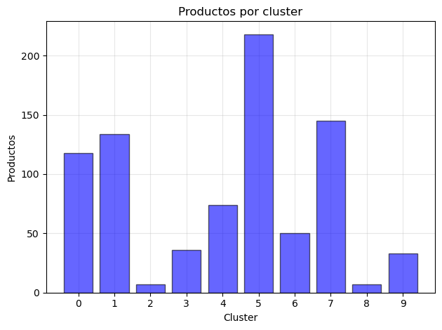

```python
# Tamaño de cada cluster
subset["cluster_kmeans"] = etiquetas
tamaños: List[int] = subset.groupby("cluster_kmeans").size().tolist()

plt.bar(
    range(n_CLUSTERS),
    tamaños,
    color="blue",
    edgecolor="black",
    linewidth=1,
    alpha=0.6
)

plt.title("Productos por cluster")
plt.xlabel("Cluster")
plt.xticks(range(n_CLUSTERS))
plt.ylabel("Productos")

plt.grid(True, alpha=0.3)
plt.gca().set_axisbelow(True)

plt.tight_layout()
plt.show()
```

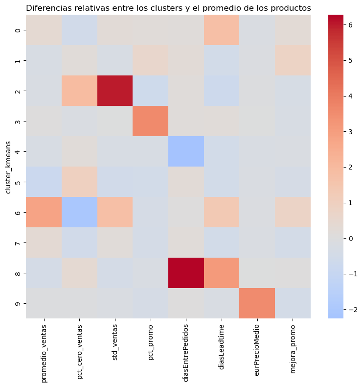

```python
# Análisis intercluster de k-means respecto al promedio de todos los productos
resumen: pd.DataFrame = subset.drop("producto", axis=1).groupby("cluster_kmeans").mean()
resumen_relativo: pd.DataFrame = (
    (resumen - subset.drop(columns=["producto", "cluster_kmeans"]).mean())
    / subset.drop(columns=["producto", "cluster_kmeans"]).std()
)

plt.figure(figsize=(8, 8))

sns.heatmap(resumen_relativo, cmap="coolwarm", center=0)

plt.title("Diferencias relativas entre los clusters y el promedio de los productos")

plt.tight_layout()
plt.show()
```

El mapa de calor representado junto con la reducción mediante *t-SNE* permiten identificar qué hace a cada grupo único y cómo se refleja esto en el espacio reducido. A continuación se listan las características importantes de cada agrupación.

- *Cluster* 0 → Presenta un tamaño considerable con más de 100 productos con un tiempo de entrega moderado
- *Cluster* 1 → Contiene una cantidad de artículos similar al grupo anterior pero con una ligera mejora de ventas cuando los productos se promocionan
- *Cluster* 2 → Es uno de los grupos más pequeños y se diferencia por una volatilidad de ventas muy grande dada por la variable *std_ventas*, donde muchos días no tienen ventas
- *Cluster* 3 → Contiene pocos productos que se caracterizan por el gran tiempo en el que están de oferta
- *Cluster* 4 → Presenta alrededor de 75 artículos con una rotación en el inventario relativamente alta
- *Cluster* 5 → Es de lejos el *cluster* más grande con más de 200 productos, donde el comportamiento es muy cercano a la media exceptuando una cantidad de ventas ligeramente por debajo del promedio del *dataset*
- *Cluster* 6 → Contiene 50 ítems y es el grupo con un promedio de ventas más grande de todos que a su vez presenta muy pocos días sin ninguna venta
- *Cluster* 7 → Con prácticamente 150 artículos, este grupo es el que presenta un comportamiento más cercano a la media de todos
- *Cluster* 8 → Este grupo es de los más pequeños y presenta el mayor ciclo de aprovisionamiento de todos, con el ciclo de reposición y los días de entrega más elevados respecto a la media del conjunto de datos
- *Cluster* 9 → Presenta menos de 50 artículos y se caracteriza por una alta concentración de ítems caros

En primer lugar, se observa que los clusters 1, 5 y 7 son los más numerosos y presentan características muy próximas a la media del conjunto de datos. Este comportamiento se refleja también en la proyección bidimensional mediante *t-SNE*, donde dichos grupos conforman la principal aglomeración de puntos situada en la zona inferior izquierda de la representación. Adicionalmente, a pesar de que no se ha incluido en la versión final del presente *notebook*, el análisis de las matrices de correlación de cada uno de estos *clusters* muestra patrones prácticamente idénticos en la relación entre las variables y la demanda. En consecuencia, se considera que las diferencias entre estos grupos no son suficientemente significativas como para justificar el entrenamiento de modelos independientes, por lo que se opta por su fusión en un único grupo, reduciendo así la complejidad del problema sin pérdida apreciable de información.

Por otro lado, también se identifican regiones bien diferenciadas en el espacio reducido. En particular, el grupo de la parte superior izquierda está compuesto mayoritariamente por productos del *cluster* 4, mientras que la zona superior derecha corresponde principalmente al *cluster* 0, lo que indica la existencia de patrones de comportamiento claramente diferenciados respecto al conjunto global. Asimismo, el *cluster* 6 presenta características similares al *cluster* 0, aunque con valores más extremos, especialmente en términos de volumen de ventas. Sin embargo, el reducido número de productos que contiene limita su utilidad para el entrenamiento de modelos de aprendizaje automático. Por este motivo, se propone fusionar ambos grupos, no solo por su proximidad en el espacio de características, sino también por la relevancia que presentan en la modelización de la demanda al concentrar productos con un número de ventas elevado.

Finalmente, el resto de *clusters* presentan un tamaño reducido y, en algunos casos, comportamientos más específicos o atípicos. Dado que no cuentan con suficientes observaciones para entrenar modelos robustos de forma individual, se opta por agruparlos en un *cluster* residual.

```python
# Se añaden las etiquetas de los nuevos clusters al subset
subset["cluster_final"] = subset["cluster_kmeans"]
subset.loc[subset["cluster_final"] == 6, "cluster_final"] = 0
subset.loc[subset["cluster_final"].isin([5, 7]), "cluster_final"] = 1
subset.loc[subset["cluster_final"].isin([3, 8, 9]), "cluster_final"] = 2
subset.loc[subset["cluster_final"] == 4, "cluster_final"] = 3

subset["cluster_nombre"] = subset["cluster_final"].astype(str)
subset.loc[subset["cluster_nombre"] == "0", "cluster_nombre"] = "top_ventas"
subset.loc[subset["cluster_nombre"] == "1", "cluster_nombre"] = "estandar"
subset.loc[subset["cluster_nombre"] == "2", "cluster_nombre"] = "residual"
subset.loc[subset["cluster_nombre"] == "3", "cluster_nombre"] = "alta_rotacion"
```

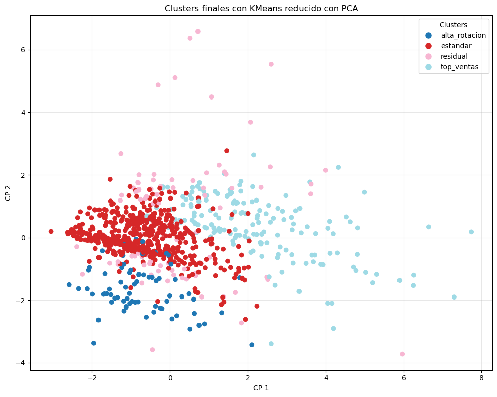

```python
# Visualización de los clusters finales con PCA
etiquetas: pd.Categorical = pd.Categorical(subset["cluster_nombre"])
codigos: np.ndarray = etiquetas.codes

cmap: Colormap = plt.cm.get_cmap("tab20", len(etiquetas.categories))

plt.figure(figsize=(10, 8))

plt.scatter(pca_x[:, 0], pca_x[:, 1], c=codigos, cmap=cmap)

plt.title("Clusters finales con KMeans reducido con PCA")
plt.xlabel("CP 1")
plt.ylabel("CP 2")

plt.grid(True, alpha=0.3)
plt.gca().set_axisbelow(True)

handles: List[Line2D] = []
for i, nombre in enumerate(etiquetas.categories):
    color: tuple[float, float, float, float] = cmap(i)

    handles.append(
        Line2D([0], [0], marker="o", linestyle="", markerfacecolor=cmap(i), markeredgecolor=cmap(i), label=nombre, markersize=8)
    )

plt.legend(handles=handles, title="Clusters")

plt.tight_layout()
plt.show()
```

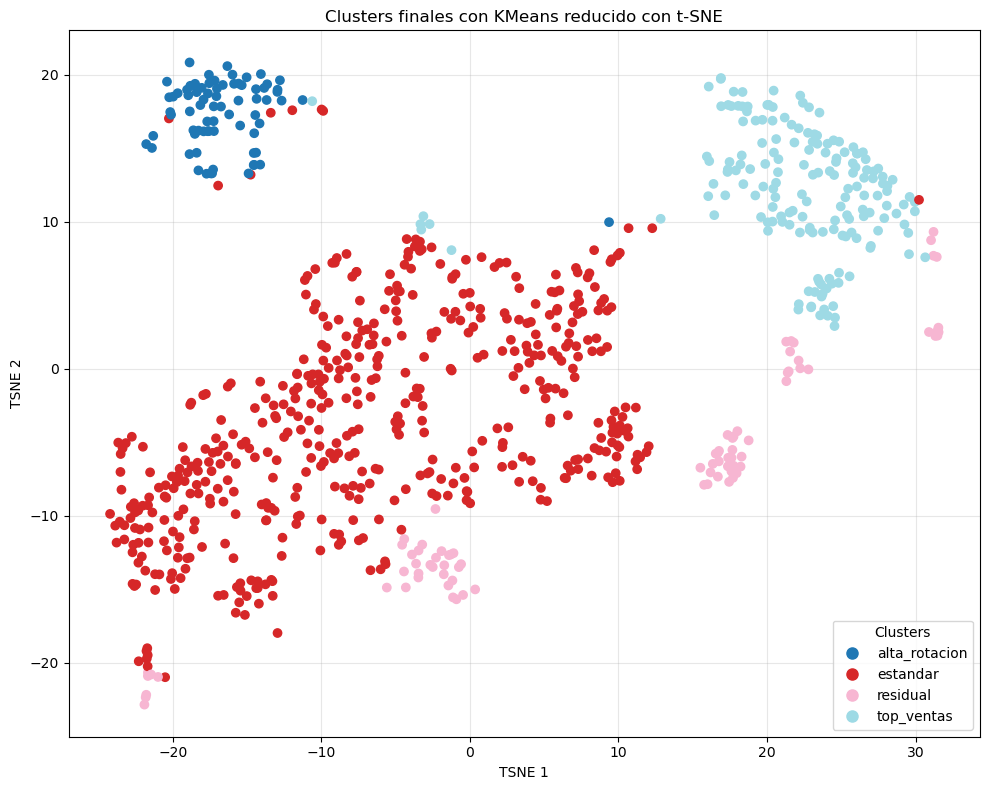

```python
# Visualización de los clusters finales con t-SNE
etiquetas: pd.Categorical = pd.Categorical(subset["cluster_nombre"])
codigos: np.ndarray = etiquetas.codes

cmap: Colormap = plt.cm.get_cmap("tab20", len(etiquetas.categories))

plt.figure(figsize=(10, 8))

plt.scatter(tsne_x[:, 0], tsne_x[:, 1], c=codigos, cmap=cmap)

plt.title("Clusters finales con KMeans reducido con t-SNE")
plt.xlabel("TSNE 1")
plt.ylabel("TSNE 2")

plt.grid(True, alpha=0.3)
plt.gca().set_axisbelow(True)

handles: List[Line2D] = []
for i, nombre in enumerate(etiquetas.categories):
    color: tuple[float, float, float, float] = cmap(i)

    handles.append(
        Line2D([0], [0], marker="o", linestyle="", markerfacecolor=cmap(i), markeredgecolor=cmap(i), label=nombre, markersize=8)
    )

plt.legend(handles=handles, title="Clusters")

plt.tight_layout()
plt.show()
```

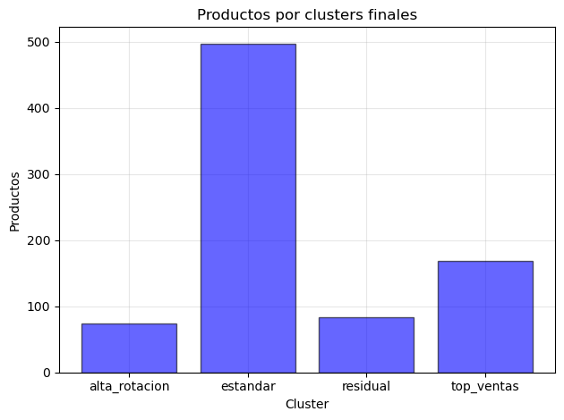

```python
# Tamaño de cada cluster final
tamaños: List[int] = subset.groupby("cluster_nombre").size().tolist()

plt.bar(
    sorted(subset["cluster_nombre"].unique()),
    tamaños,
    color="blue",
    edgecolor="black",
    linewidth=1,
    alpha=0.6
)

plt.title("Productos por clusters finales")
plt.xlabel("Cluster")
plt.xticks(range(len(subset["cluster_nombre"].unique())))
plt.ylabel("Productos")

plt.grid(True, alpha=0.3)
plt.gca().set_axisbelow(True)

plt.tight_layout()
plt.show()
```

Es importante comentar el hecho que los 4 *clusters* tienen tamaños dispares, especialmente el grupo *estandar*, que es el que acapara la mayoría de productos del *dataset*. No obstante, se considera que cada grupo contiene una cantidad de datos suficiente para poder entrenar un modelo de aprendizaje automático robusto. Por otro lado, para recapitular se listan los *clusters* finales y cómo se han formado.

- *alta_rotacion* → Representa el *cluster* 4 original
- *estandar* → Agrupa los grupo 1, 5 y 7 originales
- *residual* → Recoge los grupos 2, 3, 8 y 9 originales
- *top_ventas* → Fusión de los *clusters* 0 y 6

```python
# Se añaden las etiquetas de los clusters al dataset reconstruido
añadir: pd.DataFrame = subset[["producto", "cluster_final", "cluster_nombre"]]
dataset_final: pd.DataFrame = dataset_reconstruido.merge(añadir, on="producto", how="inner")
```

```python
# Se dicotomizan las categorías de las variables mes_int y dia_semana_str y se exporta el dataset
dataset_final["mes_str"] = dataset_final["mes_int"].astype(str)
dataset_final: pd.DataFrame = pd.get_dummies(dataset_final, columns=["mes_str", "dia_semana_str"])

dataset_final.to_csv("dataset_preprocesado.csv")
```